# hw6-tidytuesday

# Image and Summary of Visualization

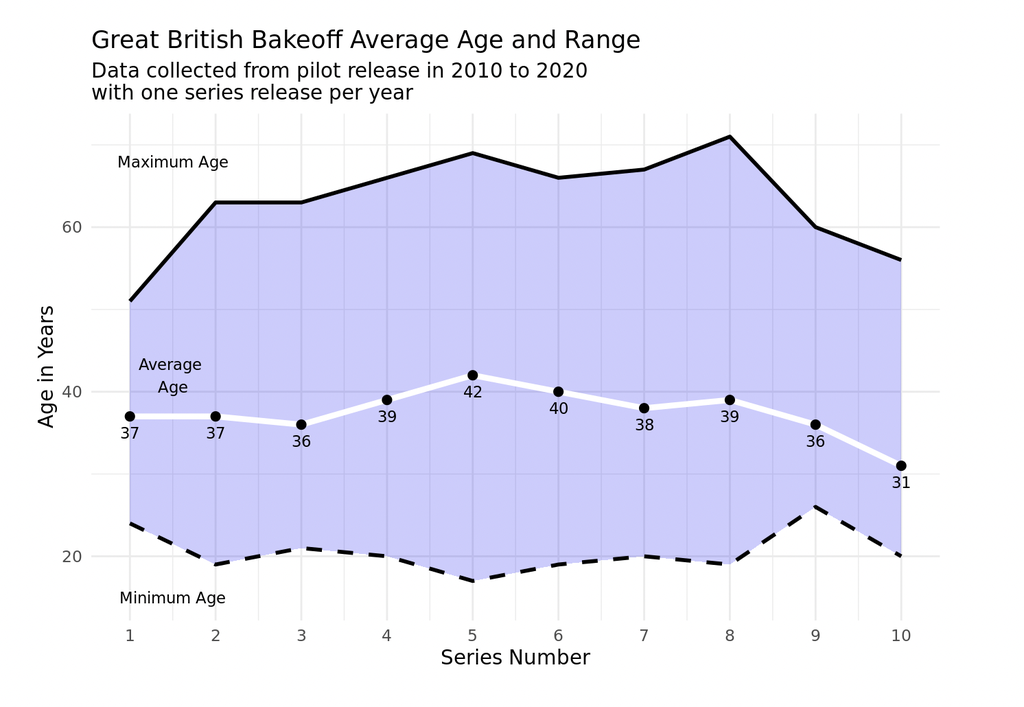

My visualization aims to understand the ages of participants for each series (season) in the tv series “The Great British Bake Off”. For each series, the graph contains the oldest and youngest baker as well as the average age of all the contestants. To better illustrate the range of ages for each season, geom_ribbon() was used to emphasize the difference between the youngest and oldest bakers. The graph illustrates four trends across all 10 series: 1) How the minimum age changes; 2) How the maximum age changes; 3) How the average age changes; 4) How the range of ages changes. With a little bit of contextual data, we can see trends possibly relating to the pandemic. The show aired in 2010 and had 10 consecutive seasons when the data set was collected in 2020. The 9th season aired in the summer of 2019, well after the pandemic had begun its initial sweep of the world. The visualization shows a decrease in maximum age; notably, this decrease came after what had been a slowly increasing maximum age for previous series. This was likely because older bakers did not want to risk their health and therefore did not apply, or the show did not want to risk the older bakers’ health and therefore did accept them. This 9th series was also the time when the minimum age of bakers was the highest, which could be related to the availability of vaccines for young people at the time.